# 數據分析的基石：使用活頁簿與資料庫玩轉結構化資料

> 簡介

[郭耀仁](https://linktr.ee/yaojenkuo) | yaojenkuo@datainpoint.com

## 課程名稱與內容簡介

## 什麼是數據分析

- 一般大眾對數據分析的認知，可能是報表、儀表板、資料探勘、統計或機器學習。
- 事實上，舉凡程式、資料載入、資料清理、資料轉換、視覺化、模型、溝通都是數據分析的範疇。
- 數據分析可以用管線流的示意圖讓我們一目瞭然。

## 管線流的示意圖

[figure not shown]

來源：https://r4ds.hadley.nz/intro.html

## 什麼是結構化資料

- 結構化資料（Structured Data）是指經過標準格式組織，具有水平的列（Rows）與垂直的欄（Columns），例如這堂課程的結構化資料：活頁簿以及資料庫。
- 在數據分析的日常工作中，絕大多數時候都是面對結構化資料。
- 能夠熟稔、靈活地處理結構化資料，是數據分析的基石。

## 什麼是活頁簿

- 活頁簿（Workbook）是 Microsoft Excel、**Google Sheets**、Apple Numbers 與 LibreOffice Calc 等主流試算表軟體的主要檔案格式。
- 一個活頁簿通常由多個工作表（Worksheet）組合而成；一個工作表則是由列（Row 由 1 起始）與欄（Column 由 A 起始）組成的二維表格。

## 什麼是資料庫

- 資料庫（Database）是一種特定、經過加工的數位資料集合，能夠放置在伺服器、個人電腦、手機或者微型電腦（例如：樹莓派）之中。
- 一個資料庫通常由多個資料表（Table）組合而成；一個資料表則是由列（Row）與欄（Column）組成的二維表格。
- 我們可以將資料庫和活頁簿對比；將資料表和工作表對比。

## 活頁簿與資料庫有什麼不同

1. 活頁簿具備更靈活的使用彈性、資料儲存格式，例如同一個欄位中的資料可以有不同的型別。
2. 資料庫具備更完善的權限管理機制，例如管理員可以新增與刪除資料，使用者僅能查詢資料。
3. 資料庫具備元資料（Metadata），我們可以藉由查詢元資料而得知資料庫與資料表的特性。

## 要讓資料庫運行，還需要搭配資料庫管理系統與 SQL

- 資料庫管理系統可以讓資料庫具有多人共用、處理大量資料、自動化讀寫與備份等功能。
- SQL（Structured Query Language）則是能夠與資料庫中所儲存資料互動（包含查詢、定義、操作與控制）的語言。

## 常見的資料庫管理系統大致可以分為商業授權與開放原始碼兩大類

- 商業授權
  - SQL Server：微軟公司（Microsoft）的資料庫管理系統。
  - Oracle Database：甲骨文公司（Oracle）的資料庫管理系統。
  - DB2：國際商業機器公司（IBM）的資料庫管理系統。
- 開放原始碼
  - **SQLite**：開放原始碼的資料庫管理系統。
  - MySQL：開放原始碼的資料庫管理系統，現為甲骨文公司所有。
  - PostgreSQL：開放原始碼的資料庫管理系統。

## 什麼是 SQL

- SQL 是 **S**tructured **Q**uery **L**anguage 的縮寫，是一個專門針對關聯式資料庫中所儲存的資料互動（包含查詢、定義、操作與控制）的語言。
- 可以唸作 "ess-cue-ell" 或 "sequel"
- SQL 在 1970 年代由國際商業機器公司（IBM）創造，剛開發出來時候僅只是為了更有效率地「查詢」儲存於關聯式資料庫中的資料，但是到了現代，除了查詢以外像是資料的建立、更新與刪除，也都能靠著 SQL 來完成。

## SQL、資料庫與資料庫管理系統三者的關係

| SQL | 資料庫 | 資料庫管理系統 |
| --- | --- | --- |
| 駕駛車的技術、執照 | 車 | 道路、車庫、交通號誌、路線管理 |
| 駕駛船的技術、執照 | 船 | 水域、船塢、港口、航線管理 |
| 駕駛飛機的技術、執照 | 飛機 | 空域、機場、停機坪、跑道、塔台、航線管理 |

## 為什麼活頁簿與資料庫是數據分析的基石

- 活頁簿具備 WYSIWYG "What You See Is What You Get" 的特性，非常適合演繹程式與分析的邏輯。
- 資料庫是數據分析最常見的資料來源之一，對於在大型企業工作的資料科學從業人員格外重要。

## 根據 Kaggle Survey，SQL 是資料科學從業人員第二常用的語言，僅次於 Python

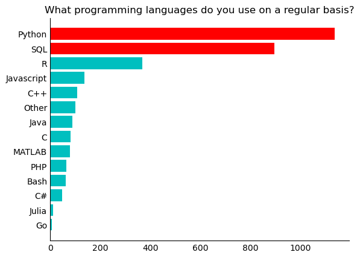

```python
from ks2022 import KaggleSurvey2022

csv_file = "kaggle_survey_2022_responses.csv"
ks = KaggleSurvey2022(csv_file)
ks.plot_survey_summary(question_index="Q12", n=2)
```

## 建立學習環境

## 活頁簿與資料庫的學習環境

- 活頁簿學習環境：Google Sheets
- 資料庫學習環境：
  - Letos
  - DB Browser for SQLite

## Letos、DB Browser for SQLite 學員可以二擇一下載安裝

- Letos：https://github.com/pawelsalawa/letos/releases
- DB Browser for SQLite：https://sqlitebrowser.org/dl

## 在 Windows 作業系統下載安裝 Letos、DB Browser for SQLite

- Letos：https://github.com/pawelsalawa/letos/releases
- DB Browser for SQLite：https://sqlitebrowser.org/dl

## 在 macOS 下載安裝 Letos、DB Browser for SQLite

- Letos：https://github.com/pawelsalawa/letos/releases
- DB Browser for SQLite：https://sqlitebrowser.org/dl

## 本課程使用 Letos

- 如果你的電腦無法安裝最新版的 Letos，可以試著下載與安裝舊一個版本號。
- 使用 DB Browser for SQLite 跟課也完全沒有問題。
- 或者使用其他支援 SQLite 的資料庫管理軟體，例如 DBeaver：https://dbeaver.io

## 學習活頁簿與學習資料庫

- [學習活頁簿超連結](https://docs.google.com/spreadsheets/d/1Ys6rNTLuuOhqoRhIe7h1ygg2W_gEo_Qg9V-hQ_acNOI/edit?usp=sharing)
- [學習資料庫下載連結](https://classroom-ppa-learn-excel-sql-with-stock-data.s3.ap-northeast-1.amazonaws.com/datasets20260818/twse.db)

## 確認學習環境能妥善運行

## 學習活頁簿

- 前往[學習活頁簿](https://docs.google.com/spreadsheets/d/1Ys6rNTLuuOhqoRhIe7h1ygg2W_gEo_Qg9V-hQ_acNOI/edit?usp=sharing)。
- 點開不同工作表，檢視資料內容。

## 學習資料庫

- 開啟 Letos
- 新增學習資料庫。
- 連線學習資料庫，檢視不同資料表名稱。
- 開啟編輯區，輸入 SQL 敘述後執行，檢視資料內容。

```
SELECT *
  FROM table_name -- 替換成不同資料表名稱
 LIMIT 5;
```

## 學習活頁簿、學習資料庫一覽

## 資料來源

- [Yahoo! 股市](https://tw.stock.yahoo.com/)
- [Yahoo! Finance](https://finance.yahoo.com/)
- [公開資訊觀測站](https://mops.twse.com.tw/mops/#/web/home)

## 學習活頁簿、學習資料庫的說明

- tickers — 台股股票代碼主檔
  - id INTEGER, PK
  - ticker TEXT — 股票代碼
  - stock TEXT — 股票名稱
  - listed_on TEXT — 上市日期

## 學習活頁簿、學習資料庫的說明（續）

- market_caps_closes — 每日市值與收盤價
  - id INTEGER, PK
  - ticker_id INTEGER, FK → tickers.id
  - recorded_on TEXT — 記錄日期
  - market_cap REAL — 市值
  - close REAL — 收盤價

## 學習活頁簿、學習資料庫的說明（續）

- trading_volumes — 每日成交量
  - id INTEGER, PK
  - ticker_id INTEGER, FK → tickers.id
  - traded_on TEXT — 交易日期
  - volume INTEGER — 成交量

## 學習活頁簿、學習資料庫的說明（續）

- y_financials — 每季財務數據
  - id INTEGER, PK
  - ticker_id INTEGER, FK → tickers.id
  - quarter_end TEXT — 季末日期
  - gross_profit REAL — 毛利
  - net_income REAL — 淨利
  - operating_margin REAL — 營業利益率
  - free_cashflow REAL — 自由現金流

## 學習活頁簿、學習資料庫的說明（續）

- inventory_turnovers — 每季存貨週轉率
  - id INTEGER, PK
  - ticker_id INTEGER, FK → tickers.id
  - quarter_end TEXT — 季末日期
  - inventory_turnover REAL — 存貨週轉率

## 學習活頁簿、學習資料庫的說明（續）

- monthly_revenues — 每月營收
  - id INTEGER, PK
  - ticker_id INTEGER, FK → tickers.id
  - month_end TEXT — 月末日期
  - monthly_revenue INTEGER — 月營收

## 重點統整

- 舉凡程式、資料載入、資料清理、資料轉換、視覺化、模型、溝通都是數據分析的範疇。
- 結構化資料（Structured Data）是指經過標準格式組織，具有水平的列（Rows）與垂直的欄（Columns），例如這堂課程的結構化資料：活頁簿以及資料庫。
- 一個活頁簿通常由多個工作表（Worksheet）組合而成；一個資料庫通常由多個資料表（Table）組合而成，我們可以將資料庫和活頁簿對比、將資料表和工作表對比。

## 重點統整（續）

- 讓資料庫運行，還需要搭配資料庫管理系統與 SQL，三者缺一不可。
- 本課程使用的是 SQLite 資料庫管理系統，但我們學會的 SQL 與資料庫知識，可以適用 MySQL、SQL Server、Oracle Database、PostgreSQL 等其他資料庫管理系統。
- 本課程的活頁簿學習環境使用 Google Sheets；資料庫學習環境使用 Letos 或 DB Browser for SQLite